# Workshop 3 [Week 6] linear regression

Notebook code chunks can be inserted quickly using the keyboard shortcut Ctrl + Alt + I (macOS: Cmd + Option + I ), or via the Insert menu in the editor toolbar.

# **************************************

# PART FOUR: CLASS EXERCISES *#* *************************************

# Jon Sadler - Mar 10th 2022

Load libraries - you might need to install them.

```r
library(tidyverse)
library(ggfortify)
library(car)
library(MuMIn)
```

# 1. Linear Regression using the faithful dataset

# look at the data in the base file

```r
str(faithful)
```

```
'data.frame':   272 obs. of  2 variables:
 $ eruptions: num  3.6 1.8 3.33 2.28 4.53 ...
 $ waiting  : num  79 54 74 62 85 55 88 85 51 85 ...
```

# plot some pictures

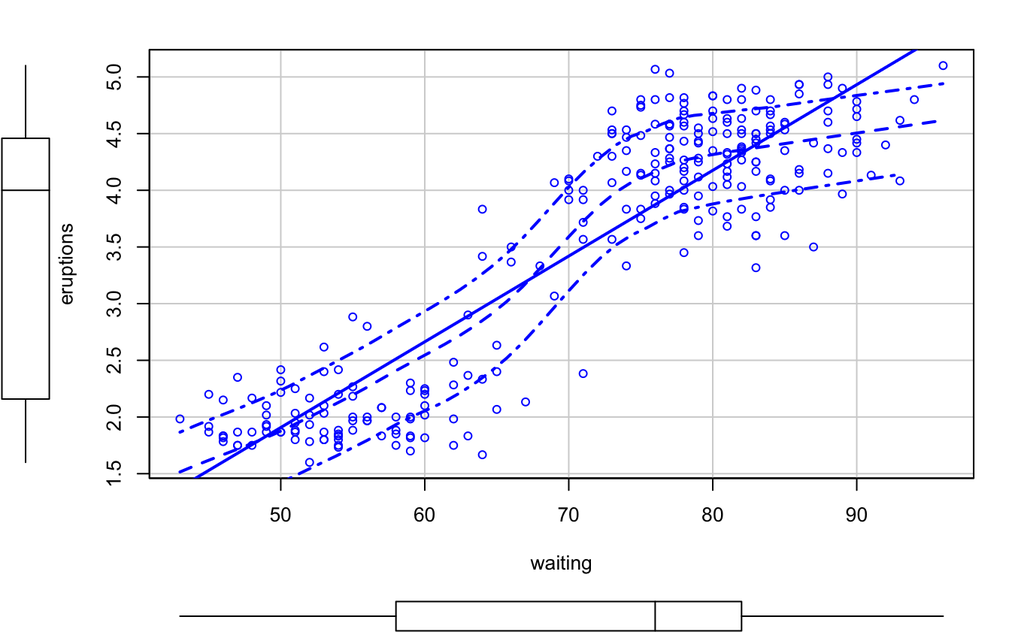

```r
scatterplot(eruptions ~ waiting, data = faithful)
```

# Looks decent in terms of the boxplots - indicates normality and homogeneity of variance

# Maybe an issue with linearity of the response to explanatory but we’ll have a look

# Using ggplot

What’s missing in this code?

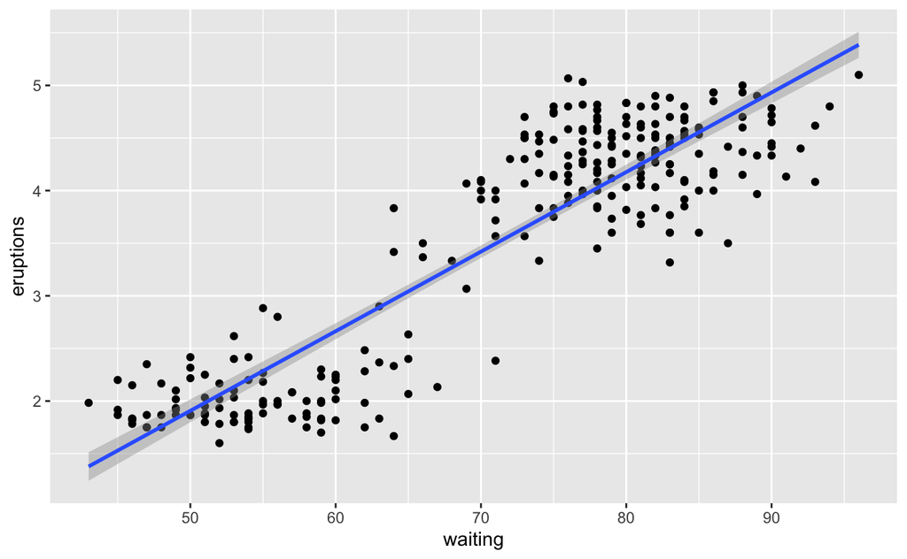

```r
ggplot(faithful,aes(waiting,eruptions)) + geom_point() + geom_smooth(method=lm)
```

# Specify and examine linear model

```r
summary(lm(eruptions ~ waiting, data = faithful))
```

```
Call:
lm(formula = eruptions ~ waiting, data = faithful)

Residuals:
     Min       1Q   Median       3Q      Max
-1.29917 -0.37689  0.03508  0.34909  1.19329

Coefficients:
             Estimate Std. Error t value Pr(>|t|)
(Intercept) -1.874016   0.160143  -11.70   <2e-16 ***
waiting      0.075628   0.002219   34.09   <2e-16 ***
---
Signif. codes:  0 ‘***’ 0.001 ‘**’ 0.01 ‘*’ 0.05 ‘.’ 0.1 ‘ ’ 1

Residual standard error: 0.4965 on 270 degrees of freedom
Multiple R-squared:  0.8115,    Adjusted R-squared:  0.8108
F-statistic:  1162 on 1 and 270 DF,  p-value: < 2.2e-16
```

```r
anova(lm(eruptions ~ waiting, data = faithful))
```

```
Analysis of Variance Table

Response: eruptions
           Df  Sum Sq Mean Sq F value    Pr(>F)
waiting     1 286.478 286.478  1162.1 < 2.2e-16 ***
Residuals 270  66.562   0.247
---
Signif. codes:  0 ‘***’ 0.001 ‘**’ 0.01 ‘*’ 0.05 ‘.’ 0.1 ‘ ’ 1
```

# write the model to an object

```r
faithful.lm <- lm(eruptions ~ waiting, data = faithful)
```

# look at plots for validation

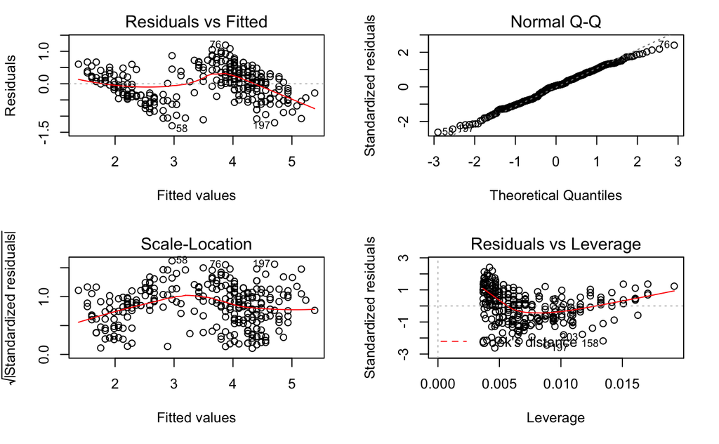

```r
par(mfrow = c(2, 2))
plot(faithful.lm)
```

# QQ-plot indicates normality

# residuals v fitted suggests limited heterogeneity that is a result of two clumps of points, but it the residuals are evenly spread either side of the zero line.

# Scale v location indicates homogeneity

# Leverage plot is fine - no serious points with excessive leverage

# same plots in ggfortify

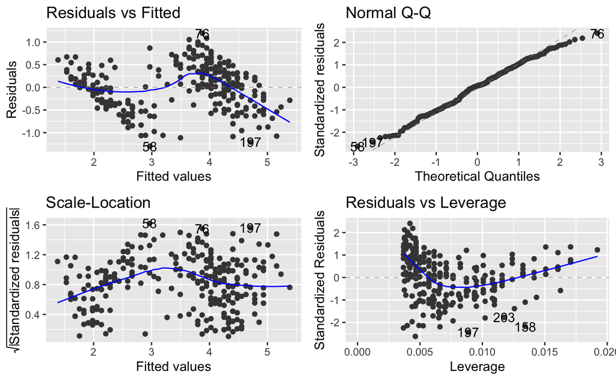

```r
autoplot(faithful.lm)
```

# plot residuals against explanatory

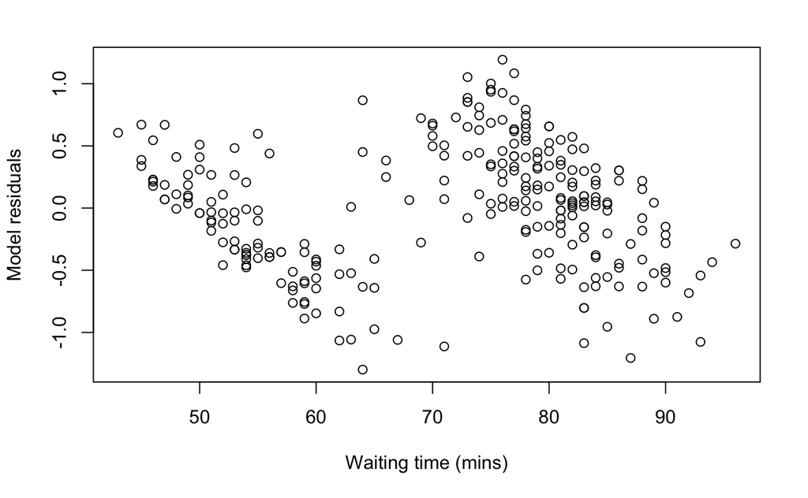

```r
plot(faithful.lm$resid ~ faithful$waiting,
     xlab = "Waiting time (mins)",
     ylab = "Model residuals")
```

Generally fine so we’ll go with it for the time being.